# Global Stuff

### Imports

```python
import pandas as pd
import seaborn as sns
from sklearn import datasets
from sklearn.linear_model import LogisticRegression
from sklearn.metrics import classification_report
from sklearn.metrics import confusion_matrix
```

### Constants

NOTE: Override this global constant as needed, to match the location of source data

```python
dataDir = './data'
```

### Manually transcribed from iris_names.txt

TODO: automate this data extraction?

```python
# column names
target = 'class'
pred = [
    'sepal length in cm',
    'sepal width in cm',
    'petal length in cm',
    'petal width in cm',
]
cols = [*pred, target]

# summary stats
summ_common_cols = ['min', 'max', 'mean', 'std']
summ_expected = pd.DataFrame(
    data=[
        [4.3, 7.9, 5.84, 0.83, 0.7826],
        [2.0, 4.4, 3.05, 0.43, -0.4194],
        [1.0, 6.9, 3.76, 1.76, 0.9490],
        [0.1, 2.5, 1.20, 0.76, 0.9565],
    ],
    index=pred,
    columns=[*summ_common_cols, 'class_corr']
)
```

### Utility Functions

```python
def print_df(df):
    with pd.option_context(
            'display.max_rows', None,
            'display.max_columns', None,
            'display.precision', 3,
        ):
        print(df)

def print_count_per_target(desc, df):
    count_per_target = df.groupby([target])[target].count()
    print(f'Count per {target} ({desc}):\n{count_per_target}\n')
    prop_per_target = count_per_target/count_per_target.sum()
    print(f'Proportion per {target} ({desc}):\n{prop_per_target}\n')
```

# Main Execution

### Load the data

```python
df = pd.read_csv(f'{dataDir}/iris_ds5230.csv', header=None, names=cols)
```

### Fix errors described in iris_names.txt (manual review)

NOTE: We do this before dropping NAs, so that the indices match.

```python
df_corrected = df.copy()
df_corrected.iloc[34,3] = 0.2
df_corrected.iloc[37,1] = 3.6
df_corrected.iloc[37,2] = 1.4
```

### Drop NAs

NOTE: We are now maintaining 3 separate DataFrames, to support multiple use cases and compare results.

```python
df_nona = df_corrected.dropna()
print(f'NA count per attribute:\n{df.isna().sum()}\n')
```

```
NA count per attribute:
sepal length in cm     7
sepal width in cm      3
petal length in cm     6
petal width in cm     10
class                 12
dtype: int64
```

### Check row counts/proportions for raw/non-NA

```python
print_count_per_target('raw data', df)
print_count_per_target('sans NAs', df_nona)
```

```
Count per class (raw data):
class
Iris-setosa        46
Iris-versicolor    46
Iris-virginica     46
Name: class, dtype: int64

Proportion per class (raw data):
class
Iris-setosa        0.333333
Iris-versicolor    0.333333
Iris-virginica     0.333333
Name: class, dtype: float64

Count per class (sans NAs):
class
Iris-setosa        36
Iris-versicolor    43
Iris-virginica     39
Name: class, dtype: int64

Proportion per class (sans NAs):
class
Iris-setosa        0.305085
Iris-versicolor    0.364407
Iris-virginica     0.330508
Name: class, dtype: float64
```

### Check Summary Stats

```python
summ_actual = df.describe().transpose()
summ_diff = summ_actual[summ_common_cols] - summ_expected[summ_common_cols]
print('Summary Stats difference:')
print_df(summ_diff)
```

```
Summary Stats difference:
                    min  max   mean        std
sepal length in cm  0.0  0.0  0.022 -5.044e-03
sepal width in cm   0.0  0.0  0.005  6.547e-03
petal length in cm  0.0  0.0  0.019  2.398e-04
petal width in cm   0.0  0.0  0.007 -6.625e-03
```

### Try a simple pair plot to look for patterns

NOTE: Iris-setosa appears to be separable, particularly on petal length/width

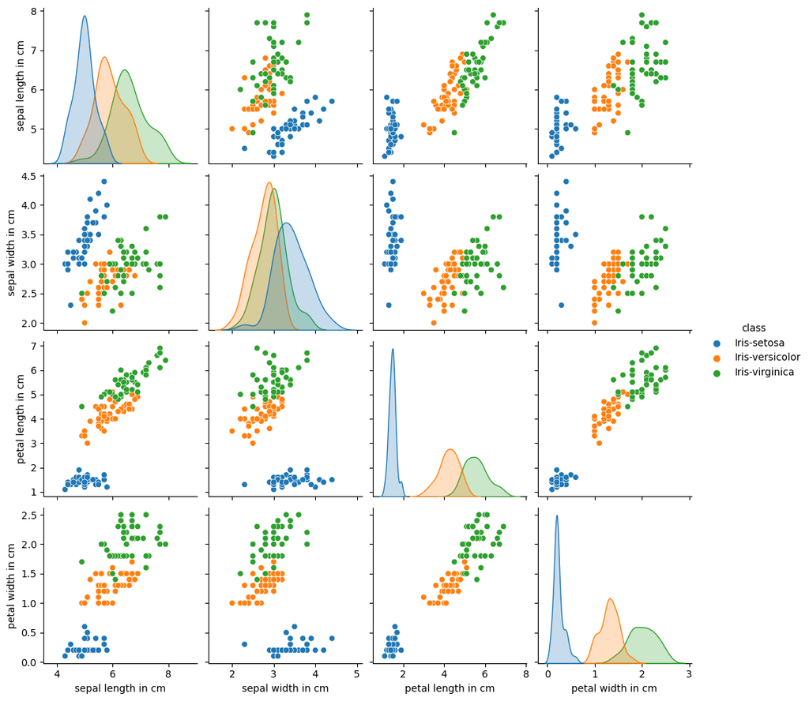

```python
sns.pairplot(df, hue='class')
```

### Try a simple logistic regression to check separability

NOTE: If classes are linearly separable per features, this should produce a perfect score.

TODO: test/train split? (would need to take support into account...)

```python
X = df_nona[pred]
y = df_nona[target]

logreg = LogisticRegression(
    multi_class='multinomial',
    random_state=42,
    solver='newton-cg',
)

logreg.fit(X,y)
y_hat = logreg.predict(X)
print(classification_report(y, y_hat))
```

```
                 precision    recall  f1-score   support

    Iris-setosa       1.00      1.00      1.00        36
Iris-versicolor       0.95      0.93      0.94        43
 Iris-virginica       0.93      0.95      0.94        39

       accuracy                           0.96       118
      macro avg       0.96      0.96      0.96       118
   weighted avg       0.96      0.96      0.96       118
```

# Compare with authoritative Iris dataset

### Get Iris dataset and convert target to string, to verify

```python
iris = datasets.load_iris()
X_iris = pd.DataFrame(iris.data, columns=iris.feature_names)
y_iris = pd.Series(data=[iris.target_names[i] for i in iris.target])
```

### Rename features and classes to match iris dataset

NOTE: using corrected data

```python
# rename features and classes to match iris dataset
# NOTE: using corrected data
X_renamed = df_corrected[pred].rename(columns={col:col.replace('in cm', '(cm)') for col in pred})
y_renamed = df_corrected[target].str.replace('Iris-', '')

# check for missing classes and errors
mismatch_ii = [i for i, v in enumerate(y_iris != y_renamed) if v]
y_na_ii = [i for i, v in enumerate(df[target].isna()) if v]
print(f'all mismatched classes are due to NA: {y_na_ii == mismatch_ii}')
```

```
all mismatched classes are due to NA: True
```

### Check for data disagreement among features

NOTE: looks good; it seems the corrections are implemented in the authoritative dataset

```python
X_diff = X_renamed - X_iris
print_df(X_diff.describe())
```

```
       sepal length (cm)  sepal width (cm)  petal length (cm)  \
count              143.0             147.0              144.0
mean                 0.0               0.0                0.0
std                  0.0               0.0                0.0
min                  0.0               0.0                0.0
25%                  0.0               0.0                0.0
50%                  0.0               0.0                0.0
75%                  0.0               0.0                0.0
max                  0.0               0.0                0.0

       petal width (cm)
count             140.0
mean                0.0
std                 0.0
min                 0.0
25%                 0.0
50%                 0.0
75%                 0.0
max                 0.0
```

### Use missing class names as a test set

NOTES:

- We could correct a couple of NAs by using the iris features, but we're focused on using the given data as much as possible.
- These results indicate that Logistic Regression can correctly recover the missing class names (where all features are present).

TODO: find more idiomatic pandas way of doing this...

```python
X_na_ii = [i for i, v in enumerate(X_renamed.isna().transpose().max()) if v]
untestable_ii = list(set(X_na_ii).intersection(set(y_na_ii)))
testable_ii = list(set(y_na_ii) - set(X_na_ii))
testable_ii.sort()
all_ii = set([i for i in range(X_renamed.shape[0])])
train_ii = list(all_ii - set(testable_ii) - set(X_na_ii))
train_ii.sort()

X_train = X_renamed.iloc[train_ii, :]
y_train = y_renamed.iloc[train_ii]
X_test = X_renamed.iloc[testable_ii, :]
y_test = y_iris[testable_ii]

logreg = LogisticRegression(
    multi_class='multinomial',
    random_state=42,
    solver='newton-cg',
)

logreg.fit(X_train, y_train)
logreg.score(X_test, y_test)
y_hat = logreg.predict(X_test)
print(classification_report(y_test, y_hat))
```

```
              precision    recall  f1-score   support

      setosa       1.00      1.00      1.00         4
  versicolor       1.00      1.00      1.00         3
   virginica       1.00      1.00      1.00         3

    accuracy                           1.00        10
   macro avg       1.00      1.00      1.00        10
weighted avg       1.00      1.00      1.00        10
```

### An idea of something a bit more idiomatic?

```python
# get the iris dataset
iris = datasets.load_iris()
X_iris = pd.DataFrame(iris.data, columns=iris.feature_names)
y_iris = pd.Series(data=iris.target, name=target)
df_iris = X_iris.copy()
df_iris[target] = y_iris

# rename features and encode classes to match iris dataset
# NOTE: using corrected data
class_ids = {f'Iris-{iris.target_names[i]}':int(i) for i, v in enumerate(iris.target_names)}
X_renamed = df_corrected[pred].rename(columns={col:col.replace('in cm', '(cm)') for col in pred})
y_renamed = df_corrected[target].map(class_ids)
df_renamed = X_renamed.copy()
df_renamed[target] = y_renamed

# check all data (numeric classes can be compared by subtraction)
print_df((df_renamed - df_iris).describe())
```

```
       sepal length (cm)  sepal width (cm)  petal length (cm)  \
count              143.0             147.0              144.0
mean                 0.0               0.0                0.0
std                  0.0               0.0                0.0
min                  0.0               0.0                0.0
25%                  0.0               0.0                0.0
50%                  0.0               0.0                0.0
75%                  0.0               0.0                0.0
max                  0.0               0.0                0.0

       petal width (cm)  class
count             140.0  138.0
mean                0.0    0.0
std                 0.0    0.0
min                 0.0    0.0
25%                 0.0    0.0
50%                 0.0    0.0
75%                 0.0    0.0
max                 0.0    0.0
```

### Confusion Matrix for missing class names

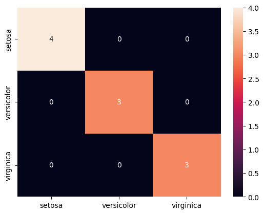

```python
conf_mat = confusion_matrix(y_test, y_hat)
conf_pd = pd.DataFrame(conf_mat, index=iris.target_names, columns=iris.target_names)
sns.heatmap(conf_pd, annot=True)
```